# Assignment 3 - basic classifiers

Math practice and coding application for main classifiers introduced in Chapter 3 of the Python machine learning book.

## Weighting

Note that this assignment is more difficult than the previous ones, and thus has a higher weighting 3 and longer duration (3 weeks). Each one of the previous two assignments has a weighting 1.

Specifically, the first 3 assignments contribute to your continuous assessment as follows:

Assignment weights: $w_1 = 1, w_2 = 1, w_3 = 3$

Assignment grades: $g_1, g_2, g_3$

Weighted average: $\frac{1}{\sum_i w_i} \times \sum_i \left(w_i \times g_i \right)$

Future assignments will be added analogously.

# RBF kernel (20 points)

Show that a Gaussian RBF kernel can be expressed as a dot product: $$ K(\mathbf{x}, \mathbf{y}) = e^\frac{-|\mathbf{x} - \mathbf{y}|^2}{2} = \phi(\mathbf{x})^T \phi(\mathbf{y}) $$ by spelling out the mapping function $\phi$.

For simplicity

- you can assume both $\mathbf{x}$ and $\mathbf{y}$ are 2D vectors $ x = \begin{pmatrix} x_1 \\ x_2 \end{pmatrix} , \; y = \begin{pmatrix} y_1 \\ y_2 \end{pmatrix} $
- we use a scalar unit variance here

even though the proof can be extended for vectors $\mathbf{x}$ $\mathbf{y}$ and general covariance matrices.

Hint: use Taylor series expansion of the exponential function

$$ \begin{align} K(\mathbf{x}, \mathbf{y}) &= exp(\frac{-|\mathbf{x} - \mathbf{y}|^2}{2}) \\ &= exp(\frac{(x-y) \cdot (x-y)}{-2}) \\ &= exp(\frac{||x||^2 + ||y||^2 -2 (x \cdot y)}{-2}) \\ &= exp(\frac{||x||^2 + ||y||^2}{-2}) \cdot exp(x \cdot y) \\ \because e^{x \cdot y} &= 1 + x \cdot y + \frac{{(x \cdot y)}^2}{2!} + \frac{{(x \cdot y)}^3}{3!} + \cdots \\ &= \sum_{i=0}^{\infty} \frac{(x \cdot y)^i}{i!} \\ \therefore K(\mathbf{x}, \mathbf{y}) &= exp(\frac{||x||^2 + ||y||^2}{-2}) \cdot exp(x \cdot y) \\ &= C \cdot \sum_{i=0}^{\infty}\frac{(x \cdot y)^i}{i!} \\ &= C \cdot \sum_{i=0}^{\infty}\frac{(x_1y_1+x_2y_2)^i}{i!} \\ &= \sum_{i=0}^{\infty}\frac{\sqrt {C}(k_1x_1+k_2x_2+k_3x_1x_2+k_4x_1^2+k_5x_2^2+ \cdots)}{\sqrt {i!}} \cdot \sum_{i=0}^{\infty}\frac{\sqrt {C}(l_1y_1+l_2y_2+l_3y_1y_2+l_4y_1^2+l_5y_2^2+ \cdots)}{\sqrt {i!}} \\ &= \phi(\mathbf{x})^T \phi(\mathbf{y}) \end{align} $$

# Kernel SVM complexity (10 points)

How would the complexity (in terms of number of parameters) of a trained kernel SVM change with the amount of training data, and why? Note that the answer may depend on the specific kernel used as well as the amount of training data. Consider specifically the following types of kernels $K(\mathbf{x}, \mathbf{y})$.

- linear: $$ K\left(\mathbf{x}, \mathbf{y}\right) = \mathbf{x}^T \mathbf{y} \\ \phi(\mathbf{x}) = \mathbf{x} $$

The complexity of linear kernel stays constant (dimension of vector n) when amount of training data changes.

- polynomial with degree $q$: $$ K\left(\mathbf{x}, \mathbf{y}\right) = (\mathbf{x}^T\mathbf{y} + 1)^q $$ Consider simple example($q$=2) and $\mathbf{x}$ and $\mathbf{y}$ are 2D vectors $ \\ x = \begin{pmatrix} x_1 \\ x_2 \end{pmatrix} , \; y = \begin{pmatrix} y_1 \\ y_2 \end{pmatrix} $: $$ \begin{align} \\ K\left(\mathbf{x}, \mathbf{y}\right) &= (\mathbf{x}^T\mathbf{y} + 1)^2 \\ &= (x_1y_1+x_2y_2+1)^2 \\ &= 1+2x_1y_1+2x_2y_2+2x_1y_1x_2y_2+x_1^2y_1^2+x_2^2y_2^2 \\ \phi(\mathbf{x}) &= [1,\sqrt 2x_1, \sqrt 2x_2, \sqrt 2x_1x_2, x_1^2, x_2^2]^T \end{align} $$ The complexity of polynomial kernel stays constant (linear with degree $q$ and dimension of vector n) when amount of training data changes.
- RBF with distance function $D$: $$ K\left(\mathbf{x}, \mathbf{y} \right) = e^{-\frac{D\left(\mathbf{x}, \mathbf{y} \right)}{2s^2}} $$

The complexity of RBF kernel grows with number of data points. From the proof done in above question, we can see $\phi (\mathbf{x})$ can be a infinite dimension vector.

# Gaussian density Bayes (30 points)

$$ p\left(\Theta | \mathbf{X}\right) = \frac{p\left(\mathbf{X} | \Theta\right) p\left(\Theta\right)}{p\left(\mathbf{X}\right)} $$

Assume both the likelihood and prior have Gaussian distributions:

$$ \begin{align} p(\mathbf{X} | \Theta) &= \frac{1}{(2\pi)^{N/2}\sigma^N} \exp\left(-\frac{\sum_{t=1}^N (\mathbf{x}^{(t)} - \Theta)^2}{2\sigma^2}\right) \\ p(\Theta) &= \frac{1}{\sqrt{2\pi}\sigma_0} \exp\left( -\frac{(\Theta - \mu_0)^2}{2\sigma_0^2} \right) \end{align} $$

Derive $\Theta$ from the dataset $\mathbf{X}$ via the following methods:

### ML (maximum likelihood) estimation

$$ \begin{align} \Theta_{ML} &= argmax_{\Theta} p(\mathbf{X} | \Theta) \end{align} $$

The Loss function $\mathbf{L}$: $$ \begin{align} \mathbf{L} &= \frac{1}{(2\pi)^{N/2}\sigma^N} \exp\left(-\frac{\sum_{t=1}^N (\mathbf{x}^{(t)} - \Theta)^2}{2\sigma^2}\right) \\ \log \mathbf{L} &= -\frac{N}{2} \log (2 \pi) - N \log (\sigma) -\frac{\sum_{t=1}^N (\mathbf{x}^{(t)} - \Theta)^2}{2\sigma^2} \\ \frac{\partial \log \mathbf{L}}{\partial \Theta} &= \frac {\sum_{t=1}^N (\mathbf{x}^{(t)} - \Theta)}{\sigma^2} \end{align} $$ For $\frac{\partial \log \mathbf{L}}{\partial \Theta} = 0$: $$ \begin{align} \sum_{t=1}^N (\mathbf{x}^{(t)} - \Theta) &= 0 \\ \sum_{t=1}^N (\mathbf{x}^{(t)}) - N\Theta &= 0 \\ \Theta &= \frac {\sum_{t=1}^N (\mathbf{x}^{(t)})}{N} = \mu \end{align} $$ which is the mean of the data set

### MAP estimation

$$ \begin{align} \Theta_{MAP} &= argmax_{\Theta} p(\Theta | \mathbf{X}) \\ &= argmax_{\Theta} p(\mathbf{X} | \Theta) p(\Theta) \end{align} $$

The loss function $\mathbf{L}$: $$ \begin{align} \mathbf{L} &= \frac{1}{(2\pi)^{N/2}\sigma^N} \exp\left(-\frac{\sum_{t=1}^N (\mathbf{x}^{(t)} - \Theta)^2}{2\sigma^2}\right) \cdot \frac{1}{\sqrt{2\pi}\sigma_0} \exp\left( -\frac{(\Theta - \mu_0)^2}{2\sigma_0^2} \right) \\ \log \mathbf{L} &= -\frac{N}{2} \log (2 \pi) - N \log (\sigma) -\frac{\sum_{t=1}^N (\mathbf{x}^{(t)} - \Theta)^2}{2\sigma^2} +\log (\frac{1}{\sqrt{2\pi}\sigma_0}) -\frac{(\Theta - \mu_0)^2}{2\sigma_0^2} \\ \frac{\partial \log \mathbf{L}}{\partial \Theta} &= \frac {\sum_{t=1}^N (\mathbf{x}^{(t)} - \Theta)}{\sigma^2} - \frac{(\Theta - \mu_0)}{\sigma_0^2} \end{align} $$ For $\frac{\partial \log \mathbf{L}}{\partial \Theta} = 0$: $$ \begin{align} \frac {\sum_{t=1}^N (\mathbf{x}^{(t)} - \Theta)}{\sigma^2} - \frac{(\Theta - \mu_0)}{\sigma_0^2} &= 0 \\ \frac {\sum_{t=1}^N (\mathbf{x}^{(t)} - \Theta)}{\sigma^2} &= \frac{(\Theta - \mu_0)}{\sigma_0^2} \\ \frac {\sum_{t=1}^N (\mathbf{x}^{(t)})}{\sigma^2} - \frac{N\Theta}{\sigma^2} &= \frac{\Theta}{\sigma_0^2} - \frac{\mu_0}{\sigma_0^2} \\ \frac{N\Theta}{\sigma^2} + \frac{\Theta}{\sigma_0^2} &= \frac{\mu_0}{\sigma_0^2}+\frac {\sum_{t=1}^N (\mathbf{x}^{(t)})}{\sigma^2} \\ \frac {(N \sigma_0^2+ \sigma^2)\Theta}{\sigma^2\sigma_0^2} &=\frac {\sigma^2 \mu_0 +\sigma_0^2 \sum_{t=1}^N (\mathbf{x}^{(t)})}{\sigma^2\sigma_0^2} \\ \Theta &= \frac {\sigma^2 \mu_0 +\sigma_0^2 \sum_{t=1}^N (\mathbf{x}^{(t)})}{(N \sigma_0^2+ \sigma^2)} \\ &= \frac {\sigma^2 \mu_0 + N\sigma_0^2 \mu}{(N \sigma_0^2+ \sigma^2)} \end{align} $$

### Bayes estimation

$$ \begin{align} \Theta_{Bayes} &= E(\Theta | \mathbf{X}) \\ &= \int \Theta p(\Theta | \mathbf{X}) d\Theta \\ &= \int \frac {\Theta p(\mathbf{X} | \Theta) p(\Theta)}{p(\mathbf{X})} d\Theta \\ &= \int \frac {\Theta \cdot \frac{1}{(2\pi)^{N/2}\sigma^N} \exp\left(-\frac{\sum_{t=1}^N (\mathbf{x}^{(t)} - \Theta)^2}{2\sigma^2}\right) \cdot \frac{1}{\sqrt{2\pi}\sigma_0} \exp\left( -\frac{(\Theta - \mu_0)^2}{2\sigma_0^2} \right)}{p(\mathbf{X})} d\Theta \\ &= \frac{1}{(2\pi)^{N/2}\sigma^N} \cdot \frac{1}{\sqrt{2\pi}\sigma_0} \cdot \frac{1}{p(\mathbf{X})} \int \Theta \cdot \exp\left(-\frac{\sum_{t=1}^N (\mathbf{x}^{(t)} - \Theta)^2}{2\sigma^2}\right) \cdot \exp\left( -\frac{(\Theta - \mu_0)^2}{2\sigma_0^2} \right) d\Theta \\ &= C \int \Theta \cdot \exp\left(-\frac{\sum_{t=1}^N (\mathbf{x}^{(t)} - \Theta)^2}{2\sigma^2}\right) \cdot \exp\left( -\frac{(\Theta - \mu_0)^2}{2\sigma_0^2} \right) d\Theta \\ \exp\left(-\frac{\sum_{t=1}^N (\mathbf{x}^{(t)} - \Theta)^2}{2\sigma^2}\right) \cdot \exp\left( -\frac{(\Theta - \mu_0)^2}{2\sigma_0^2} \right) &= \exp\left(-\frac{\sum_{t=1}^N (\mathbf{x}^{(t)} - \mu)^2 + (\mu - \Theta)^2}{2\sigma^2}\right) \cdot \exp\left( -\frac{(\Theta - \mu_0)^2}{2\sigma_0^2} \right) \\ &= \exp\left(-\frac{N \sigma^2 + N(\mu-\Theta)^2}{2\sigma^2} -\frac{(\Theta - \mu_0)^2}{2\sigma_0^2} \right) \\ &= \exp\left[-\frac{1}{2} (N - \frac{N( \mu-\Theta)^2}{\sigma^2} + \frac{(\Theta-\mu_0)^2}{\sigma_0^2})\right] \\ &= \exp\left[-\frac{1}{2} (N - \frac{N\mu^2-2N\mu\Theta+N\Theta^2}{\sigma^2} + \frac{\Theta^2-2\mu_0\Theta+\mu_0^2}{\sigma_0^2})\right] \\ &= \exp\left[-\frac{1}{2}\left((\frac{1}{\sigma_0^2}-\frac{N}{\sigma^2})\Theta^2-2(\frac{\mu_0}{\sigma_0^2}+\frac{N\mu}{\sigma^2})\Theta + N + \frac{N\mu^2}{\sigma^2} + \frac{\mu_0^2}{\sigma_0^2}\right)\right] \\ &= \exp\left[-\frac{1}{2}\left((\Theta - (\frac{N/\sigma^2}{N/\sigma^2 + 1/\sigma_0^2} \mu + \frac{1/\sigma_0^2}{N/\sigma^2 + 1/\sigma_0^2} \mu_0))^2 + N + \frac{N\mu^2}{\sigma^2} + \frac{\mu_0^2}{\sigma_0^2} - \frac{(\frac{N \mu}{\sigma^2}+\frac{\mu_0}{\sigma_0^2})^2}{4}\right)\right] \\ \Theta_{Bayes} &= C \int \Theta \cdot \exp\left[-\frac{1}{2}\left((\Theta - (\frac{N/\sigma^2}{N/\sigma^2 + 1/\sigma_0^2} \mu + \frac{1/\sigma_0^2}{N/\sigma^2 + 1/\sigma_0^2} \mu_0))^2 + N + \frac{N\mu^2}{\sigma^2} + \frac{\mu_0^2}{\sigma_0^2} - \frac{(\frac{N \mu}{\sigma^2}+\frac{\mu_0}{\sigma_0^2})^2}{4}\right)\right] d\Theta \end{align} $$

Let $Y = \Theta - \frac{N/\sigma^2}{N/\sigma^2 + 1/\sigma_0^2} \mu + \frac{1/\sigma_0^2}{N/\sigma^2 + 1/\sigma_0^2} \mu_0$, $K = \frac{N/\sigma^2}{N/\sigma^2 + 1/\sigma_0^2} \mu + \frac{1/\sigma_0^2}{N/\sigma^2 + 1/\sigma_0^2} \mu_0$(shorthand) $$ \begin{align} \Theta_{Bayes} &= C \cdot \int_{-\infty}^{\infty} (Y+K) \exp\left[-\frac{1}{2}\left(Y^2 + N + \frac{N\mu^2}{\sigma^2} + \frac{\mu_0^2}{\sigma_0^2} - \frac{(\frac{N \mu}{\sigma^2}+\frac{\mu_0}{\sigma_0^2})^2}{4}\right)\right]dY \\ &= C \cdot \int_{-\infty}^{\infty} Y \exp\left[-\frac{1}{2}\left(Y^2 + N + \frac{N\mu^2}{\sigma^2} + \frac{\mu_0^2}{\sigma_0^2} - \frac{(\frac{N \mu}{\sigma^2}+\frac{\mu_0}{\sigma_0^2})^2}{4}\right)\right]dY (Odd function = 0) + C \cdot \int_{-\infty}^{\infty} K \exp\left[-\frac{1}{2}\left(Y^2 + N + \frac{N\mu^2}{\sigma^2} + \frac{\mu_0^2}{\sigma_0^2} - \frac{(\frac{N \mu}{\sigma^2}+\frac{\mu_0}{\sigma_0^2})^2}{4}\right)\right]dY \\ &=C \cdot K \int_{-\infty}^{\infty} \exp\left[-\frac{1}{2}\left(Y^2 + N + \frac{N\mu^2}{\sigma^2} + \frac{\mu_0^2}{\sigma_0^2} - \frac{(\frac{N \mu}{\sigma^2}+\frac{\mu_0}{\sigma_0^2})^2}{4}\right)\right]dY \\ &= K \cdot \frac{1}{(2\pi)^{N/2}\sigma^N} \cdot \frac{1}{\sqrt{2\pi}\sigma_0} \cdot \sqrt{2\sigma_0^2\pi} exp(\frac{(x-\mu_0)^2}{2\sigma_0^2}) \int_{-\infty}^{\infty} \exp\left[-\frac{1}{2}\left(Y^2 + N + \frac{N\mu^2}{\sigma^2} + \frac{\mu_0^2}{\sigma_0^2} - \frac{(\frac{N \mu}{\sigma^2}+\frac{\mu_0}{\sigma_0^2})^2}{4}\right)\right]dY \\ &= K (PDF = 1) \\ &= \frac{N/\sigma^2}{N/\sigma^2 + 1/\sigma_0^2} \mu + \frac{1/\sigma_0^2}{N/\sigma^2 + 1/\sigma_0^2} \mu_0 \end{align} $$

# Hand-written digit classification (40 points)

In the textbook sample code we applied different scikit-learn classifers for the Iris data set.

In this exercise, we will apply the same set of classifiers over a different data set: hand-written digits. Please write down the code for different classifiers, choose their hyper-parameters, and compare their performance via the accuracy score as in the Iris dataset. Which classifier(s) perform(s) the best and worst, and why?

The classifiers include:

- perceptron
- logistic regression
- SVM
- decision tree
- random forest
- KNN
- naive Bayes

The dataset is available as part of scikit learn, as follows.

## Load data

```python
from sklearn.datasets import load_digits
digits = load_digits()

X = digits.data # training data
y = digits.target # training label

print(X.shape)
print(y.shape)
```

```
(1797, 64)
(1797,)
```

## Visualize data

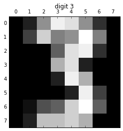

```python
%matplotlib inline
import pylab as pl

index = 13
pl.gray()
pl.matshow(digits.images[index])
pl.title('digit ' + str(digits.target[index]))
pl.show()
```

## Date Preprocessing

Hint: How you divide training and test data set? And apply other techinques we have learned if needed. You could take a look at the Iris data set case in the textbook.

```python
#Your code comes here
from sklearn.cross_validation import train_test_split

# splitting data into 70% training and 30% test data:
X_train, X_test, y_train, y_test = train_test_split(
    X, y, test_size=0.3, random_state=0)

from sklearn.preprocessing import StandardScaler

# standardize training data
sc = StandardScaler()
sc.fit(X_train)
X_train_std = sc.transform(X_train)
X_test_std = sc.transform(X_test)

# the following code is used to show how many data in each sets
# num_training = y_train.shape[0]
# num_test = y_test.shape[0]
# print('training: ' + str(num_training) + ', test: ' + str(num_test))
```

## Classifier #1 Perceptron

```python
#Your code, including traing and testing, to observe the accuracies.
from sklearn.linear_model import Perceptron

p = Perceptron(n_iter = 10)
p.fit(X_train_std, y_train)

print("Accuracy: "+str(p.score(X_test_std, y_test)))
```

```
Accuracy: 0.914814814815
```

## Classifier #2 Logistic Regression

```python
#Your code, including traing and testing, to observe the accuracies.
from sklearn.linear_model import LogisticRegression

lr = LogisticRegression(C=1000.0, random_state=0)
lr.fit(X_train_std, y_train)

print("Accuracy: "+str(lr.score(X_test_std, y_test)))
```

```
Accuracy: 0.935185185185
```

## Classifier #3 SVM

```python
#Your code, including traing and testing, to observe the accuracies.
from sklearn.svm import SVC

svm = SVC(kernel='linear', C=1.0, random_state=0)
svm.fit(X_train_std, y_train)

print("Accuracy: "+str(svm.score(X_test_std, y_test)))
```

```
Accuracy: 0.97037037037
```

## Classifier #4 Decision Tree

```python
#Your code, including traing and testing, to observe the accuracies.
from sklearn.tree import DecisionTreeClassifier

tree = DecisionTreeClassifier(criterion='entropy')
tree.fit(X_train_std, y_train)

print("Accuracy: "+str(tree.score(X_test_std, y_test)))
```

```
Accuracy: 0.85
```

## Classifer #5 Random Forest

```python
#Your code, including traing and testing, to observe the accuracies.
from sklearn.ensemble import RandomForestClassifier

forest = RandomForestClassifier(criterion='entropy',
                                n_estimators=10,
                                random_state=1,
                                n_jobs=2)
forest.fit(X_train_std, y_train)

print("Accuracy: "+str(forest.score(X_test_std, y_test)))
```

```
Accuracy: 0.940740740741
```

## Classifier #6 KNN

```python
#Your code, including traing and testing, to observe the accuracies.
from sklearn.neighbors import KNeighborsClassifier

knn = KNeighborsClassifier(n_neighbors=5, p=2, metric='minkowski')
knn.fit(X_train_std, y_train)

print("Accuracy: "+str(knn.score(X_test_std, y_test)))
```

```
Accuracy: 0.97037037037
```

## Classifier #7 Naive Bayes

```python
#Your code, including traing and testing, to observe the accuracies.
from sklearn.naive_bayes import GaussianNB

gnb = GaussianNB()

_ = gnb.fit(X_train_std, y_train)

print("Accuracy: "+str(gnb.score(X_test_std, y_test)))
```

```
Accuracy: 0.768518518519
```

Accuracy:

- Perceptron: 0.914814814815
- Logistic Regression: 0.935185185185
- SVM: 0.97037037037
- Decision tree: 0.85
- Random forest: 0.940740740741
- KNN: 0.97037037037
- Naive Bayes: 0.768518518519

Best performance: SVM/KNN

Worst performance: Naive Bayes